# Tema 3 - Variables Aleatorias discretas

## Introducción a las variables aleatorias

## Introducción

- Hasta ahora nuestros sucesos han sido de varios tipos: \(\{C,+\}\) en la moneda, marca preferida, puntuaciones a una película en una web, número de veces que sale cara en el lanzamiento de una moneda etc.
- Necesitamos estandarizar de alguna manera todos estos sucesos. Una solución es asignar a cada suceso un cierto conjunto de números reales, es decir, convertir todos los sucesos en *sucesos de números reales* para trabajar con ellos de forma unificada.
- Para conseguirlo utilizaremos unas funciones que transformen los elementos del espacio muestral en números; esta funciones son las variables aleatorias.

## Definición de variable aleatoria

Comenzaremos dando una definición poco rigurosa, pero suficiente, de variable aleatoria.

Variable Aleatoria (definición práctica)

Una variable aleatoria (v.a.) es una aplicación que toma valores numéricos determinados por el resultado de un experimento aleatorio

**Notación**:

- Normalmente representaremos las v.a. por letras mayúsculas \(X,Y,Z\ldots\)
- Los valores que “*toman*” las v.a. los representaremos por letras minúsculas (las mismas en principio) \(x,y,z\ldots\)

## Ejemplo

**Ejemplo**

Lanzamos un dado convencional de parchís el espacio muestral del experimento es

\[\Omega=\{1,2, 3, 4, 5, 6\}.\]

- Ahora el suceso \(A=\{2, 4, 6\}\), es decir “salir número par”, es equivalente a \(\{X=2,X=4,X=6\}\).
- El suceso \(B=\{1,2,3\}\), es decir “salir un número inferior o igual a \(3\)” es en términos de la v.a. \(\{X=1,X=2,X=3\}\) o también \(\{X\leq 3\}\).

## Ejemplo

**Ejemplo**

Consideremos el experimento lanzar una anilla al cuello de una botella. Si acertamos a ensartar la anilla en la botella el resultado del experimento es **éxito** y **fracaso** en caso contrario.

El espacio muestral asociado a este experimento será \(\Omega=\{\mbox{Éxito, Fracaso}\}\). Construyamos la siguiente variable aleatoria:

\[X:\{\mbox{Éxito, Fracaso}\}\to\mathbb{R}\]

definida por

\[X(\mbox{Éxito})=1 \mbox{ y } X(\mbox{Fracaso})=0.\]

## Tipos de variables aleatorias

Hay dos tipos fundamentales de variables aleatorias, las discretas y las continuas.

Damos a continuación una definición informal.

Variables Aleatorias Discretas y Continuas

- Una variable aleatoria es **discreta** si sólo puede tomar una cantidad numerable de valores con probabilidad positiva.
- Las variables aleatorias **continuas** toman valores en intervalos.
- También existen las variables aleatorias **mixtas**; con una parte discreta y otra continua.

## Ejemplo

**Ejemplo**

Son variables *aleatorias discretas*:

- Número de artículos defectuosos en un cargamento.
- Número de clientes que llegan a una ventanilla de un banco en una hora.
- Número de errores detectados en las cuentas de una compañía.
- Número de reclamaciones de una póliza de un seguro médico.

Son variables *aleatorias continuas*:

- Renta anual de una familia.
- Cantidad de petróleo importado por un país.
- Variación del precio de las acciones de una compañía de telecomunicaciones.
- Porcentaje de impurezas en un lote de productos químicos.

## Variables aleatorias discretas

## Función de probabilidad para variables discretas

**Función de Probabilidad**

La **función de probabilidad** (*probability mass function* o incluso abusando de notación *probability density function*) de una variable aleatoria discreta \(X\) a la que denotaremos por \(P_{X}(x)\) está definida por

\[P_{X}(x)=P(X=x),\]

es decir la probabilidad de que \(X\) tome el valor \(x\).

Si \(X\) no asume ese valor \(x\), entonces \(P_{X}(x)=0\).

## Función de probabilidad discreta

**Dominio de una variable aleatoria discreta**

El conjunto \[D_X=\{ x\in\mathbb{R} \mid P_X(x)>0\}\] recibe el nombre de **dominio** de la v.a. y son los valores posibles de esta variable.

En el caso discreto lo más habitual es que \(X(\Omega)=D_X\).

## Propiedades de la función de probabilidad.

Propiedades básicas de la función de probabilidad

Sea \(X\) una v.a. discreta \(X:\Omega \to\mathbb{R}\) con dominio \(D_X\). Su función de probabilidad \(P_{X}\) verifica las siguientes propiedades:

- \(0\leq P_{X}(x)\leq 1\) para todo \(x\in\mathbb{R},\)
- \(\sum\limits_{x\in D_X} P_{X}(x)=1.\)
- Dado \(A\subset D_X\) \(P(X\in A)=\sum_{x\in A} P_X(x)=\sum_{x\in A} P(X=x)\)

## Función de distribución de variables aleatorias

Distribución de Probabilidad

La función de *distribución de probabilidad* (acumulada) de la v.a. \(X\) (de cualquier tipo; discreta o continua) \(F_{X}(x)\) representa la probabilidad de que \(X\) tome un menor o igual que \(x\), es decir,

\[F_{X}(x)=P(X\leq x).\]

Esta función también se denomina función de **distribución de probabilidad o simplemente función de distribución** de una v.a., y en inglés *cumulative distribution function* por lo que se abrevia con el acrónimo `cdf`.

## Propiedades

Propiedades de la Función de Distribución

Sea \(X\) una v.a. y \(F_{X}\) su función de distribución:

- \(0\leq F_X(x)\leq 1\).
- Si \(X\) es discreta entonces \(F_X(x)=P(X\leq x)= \displaystyle \sum_{x'\in D_X | x'\leq x} P_X(x').\)
- \(P(X>x)=1-P(X\leq x)=1-F_{X}(x).\)
- Sea a y b tales que \(a<b\), \(P(a<X\leq b)=P(X\leq b)-P(X\leq a)=F_{X}(b)-F_{X}(a).\)

## Propiedades

**Propiedades de la Función de Distribución**

- La función \(F_{X}\) es no decreciente. Es decir si \(x<x'\), entonces \[F_{X}(x)\leq F_{X}(x').\] Es una función creciente,es decir, no necesariamente estrictamente creciente.
- La función \(F_{X}\) es continua por la derecha.
- Se cumple que \(\displaystyle \lim_{x\to\infty} F_{X}(x)=1\); \(\displaystyle \lim_{x\to-\infty}F_{X}(x)=0\).
- Si denotamos por \(F_X(x_0^{-})=\displaystyle \lim_{x\to x_0^{-}} F(x)\), entonces se cumple que \(P(X< x_0)=F_X(x_0^{-})\) y que \(P(X=x_0)=F_X(x_0)-F_X(x_0^{-})\).

## Valores esperados o esperanza

## Esperanza de un variable aleatoria discreta

Esperanza de una variable aleatoria discreta

El valor **esperado o esperanza** (*expected value* en inglés) \(E(X)\) de una v.a. discreta \(X\), se define como

\[ E(X)=\sum_{x\in D_X} x\cdot P_{X}(x). \]

En ocasiones se denomina **media** (*mean* en inglés,) poblacional o simplemente media y muy frecuentemente se la denota \(\mu_{X}=E(X)\) o simplemente \(\mu=E(X)\).

## Esperanzas de funciones de variables aleatorias discretas

Esperanzas de funciones de variables aleatorias discretas

Sea \(X\) una v.a. discreta con función de probabilidad \(P_{X}\) y de distribución \(F_{X}\). Entonces el *valor esperado de una función* \(g(x)\) es:

\[E(g(X))=\sum_{x}g(x) \cdot P_{X}(x).\]

## Propiedades de los valores esperados

Propiedades

- \(E(k)=k\) para cualquier constante \(k\).
- Si \(a\leq X\leq b\) entonces \(a\leq E(X)\leq b\).
- Si \(X\) es una v.a. discreta que toma valores enteros no negativos entonces \(E(X)=\sum_{x=0}^{+\infty}(1- F_X(x)).\)

## Varianza y desviación típica

## Varianza y desviación típica

Varianza

Sea \(X\) una v.a. Llamaremos **varianza** de \(X\) a

\[Var(X)=E((X-E(X))^2).\]

Por lo tanto, la varianza es el momento central de orden \(2\).

De forma frecuente se utiliza la notación \[\sigma_{X}^2=Var(X).\]

A la raíz cuadrada positiva de la varianza \[\sigma_{X}=+\sqrt{Var(X)}.\]

se la denomina desviación típica o estándar de \(X\).

## Propiedades de la varianza

Propiedad

- Si \(X\) es una v.a. discreta con función de probabilidad \(P_X\) su varianza es \[\sigma_{X}^2=Var(X)=E((X-E(X))^2)=\sum_{x}(x-E(X))^2 \cdot P_{X}(x).\]
- Sea \(X\) una v.a. \[Var(X)=E(X^2)-(E(X))^2=\sum_{x} x^2\cdot P_{X}(X)-(E(X))^2\]

## Propiedades de la varianza

**Propiedades de la varianza**

- \(Var(X)\geq 0\).
- \(Var(cte)=E(cte^2)-(E(cte))^2= cte^2 - cte^2=0\).
- El mínimo de \(E((X-C)^2)\) se alcanza cuando \(C=E(X)\) y es \(Var(X)\). Esta propiedad es una de las que hace útil a la varianza como medida de dispersión.

## Esperanza y varianza de transformaciones lineales.

## Transformaciones lineales.

Transformación lineal

Un **cambio de variable lineal** o **transformación lineal** de una v.a. \(X\) es otra v.a. \(Y= a+ b\cdot X\) donde \(a,b\in\mathbb{R}\).

Esperanza de una transformación lineal

Sea \(X\) una v.a. con \(E(X)=\mu_{X}\) y \(Var(X)=\sigma_{X}^2\) y \(a,b\in\mathbb{R}\). Entonces si \(Y=a+b\cdot X\):

- \(E(Y)=E(a + b X)=a+ b E(X)= a + b \cdot \mu_{X}\).
- \(Var(Y)=Var(a+bX)=b^2 Var(X)= b^2\cdot \sigma_{X}^2\).
- \(\sigma_{Y}=\sqrt{Var(Y)}=\sqrt{b^2 Var(X)}=|b| \cdot \sigma_{X}\).

## Distribuciones discretas notables

## Variable aleatoria Bernoulli

| \(X\) Bernoulli | \(Ber(p)\) |
| --- | --- |
| \(D_X=\) | \(\{0,1\}\) |
| \(P_X(x)=P(X=x)=\) | \(\left\{\begin{array}{ll} q & \mbox{si } x=0\\ p & \mbox{si } x=1\\0 & \mbox{en otro caso}\end{array}\right.\) |
| \(F_X(x)=P(X\leq X)=\) | \(\left\{\begin{array}{ll} 0 & \mbox{ si } x<0\\q & \mbox{ si } 0\leq x<1\\1 & \mbox{ si } 1\leq x \end{array}\right.\) |
| \(E(X)=p\) | \(Var(X)=p\cdot q\) |

## Distribución Bernoulli.

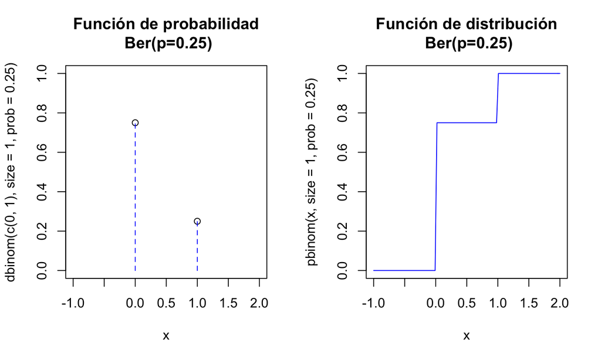

## Variable aleatoria binomial \(B(n,p)\)

| \(X\) binomial | \(B(n,p)\) |
| --- | --- |
| \(D_X=\) | \(\{0,1,\ldots n\}\) |
| \(P_X(x)=P(X=x)=\) | \(\left\{\begin{array}{ll}{n\choose x}\cdot p^x\cdot (1-p)^{n-x} & \mbox{ si } x=0,1,\ldots,n\\0 & \mbox{ en otro caso.}\end{array}\right.\) |
| \(F_X(x)=P(X\leq X)=\) | no tiene fórmula |
| \(E(X)=\) | \(n\cdot p\) |
| \(Var(X)=\) | \(n\cdot p \cdot (1-p)\) |

## Gráficas de la distribución binomial

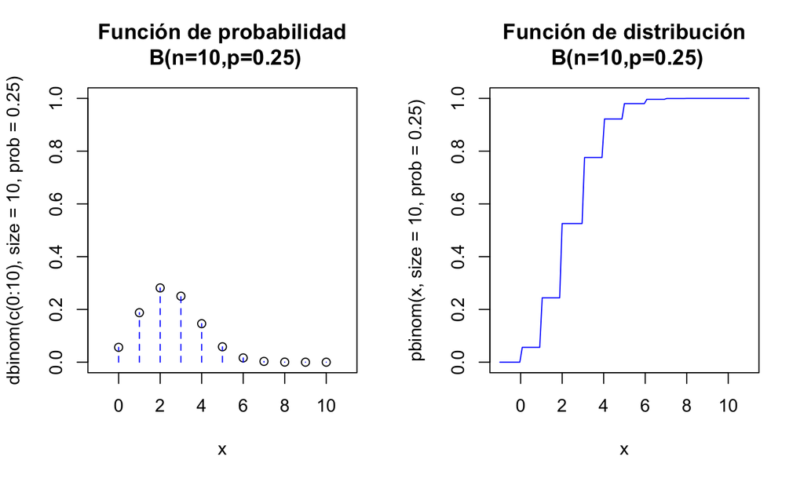

## Resumen \(Ge(p)\)

| \(X=\) Geométrica (empieza en \(0\)) | número de fracasos para conseguir el primer éxito |
| --- | --- |
| \(D_X=\) | \(\{0,1,\ldots n,\ldots\}\) |
| \(P_X(x)=P(X=x)=\) | \(\left\{\begin{array}{ll}(1-p)^{x}\cdot p & \mbox{ si } x=0,1,2,\ldots \\0 & \mbox{ en otro caso.}\end{array}\right.\) |
| \(F_X(x)=P(X\leq X)=\) | \(\left\{\begin{array}{ll} 0 & \mbox{ si } x<0\\ 1- (1-p)^{k+1} & \mbox{ si } \left\{ \begin{array}{l}k\leq x< k+1\\\mbox{para } k=0,1,2,\ldots\end{array} \right.\end{array}\right.\) |
| \(E(X)=\frac{1-p}{p}\) | \(Var(X)=\frac{1-p}{p^2}\) |

## Propiedad de la falta de memoria

Propiedad de la falta de memoria

Sea \(X\) una v.a. discreta con dominio \(D_X=\{0,1,2,\ldots\}\), con \(P(X=0)=p\).

Entonces \(X\) sigue una ley \(Ge(p)\) si, y sólo si, \[ P\left(X> k+j\big| X\geq j\right)=P(X> k) \] para todo \(k,j=0,1,2,3\ldots\).

## Gráficos

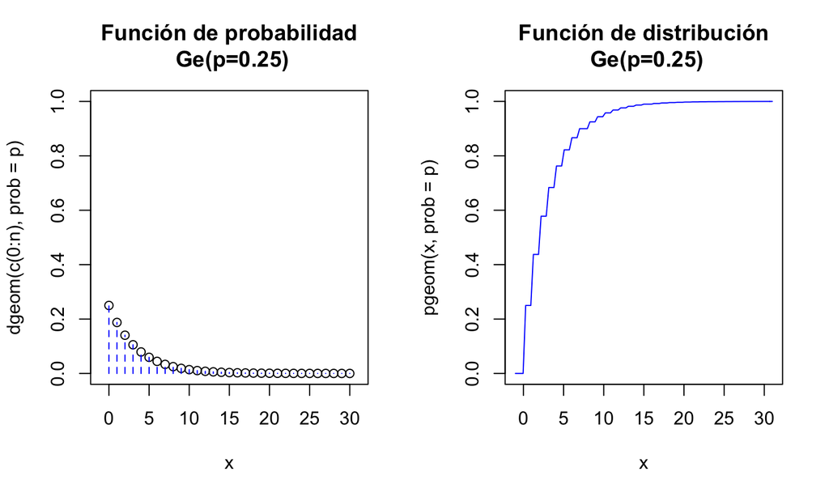

## Distribución Poisson \(X\equiv Po(\lambda)\)

[output not shown]

## Gráficos de la distribución Poisson

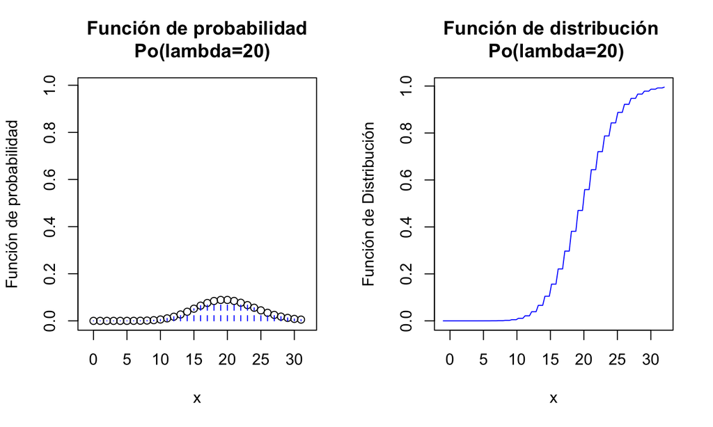

## Distribución hipergeométrica \(H(m,n,k)\).

| \(X=\)número de éxitos en \(k\) intentos sin reposición de entre \(m\) casos de éxito y \(n\) de fracaso. | \(H(m,n,k)\) |
| --- | --- |
| \(D_X\)= | \(\left\{x\in\mathbf{N}\mid \max\{0,k-n\}\leq x \leq \min\{m,k\}\right\}\) |
| \(P_X(x)=P(X=x)=\) | \(\left\{ \begin{array}{ll} \frac{\binom{m}{x}\cdot \binom{n}{k-x}}{\binom{m+n}{k}}, & \mbox{ si } \max\{0,k-n\}\leq x \leq \min\{m,k\}, \\ 0, & \mbox{en otro caso.}\end{array}\right.\) |
| \(F_X(x)=P(X\leq x)\) | No tiene una expresión explícita. |
| \(E(X)=\frac{k\cdot m}{m+n}\) | \(Var(X)=k\cdot\frac{m}{m+n}\cdot\left(1-\frac{m}{m+n}\right) \cdot\frac{m+n-k}{m+n-1}\) |

## Gráficas

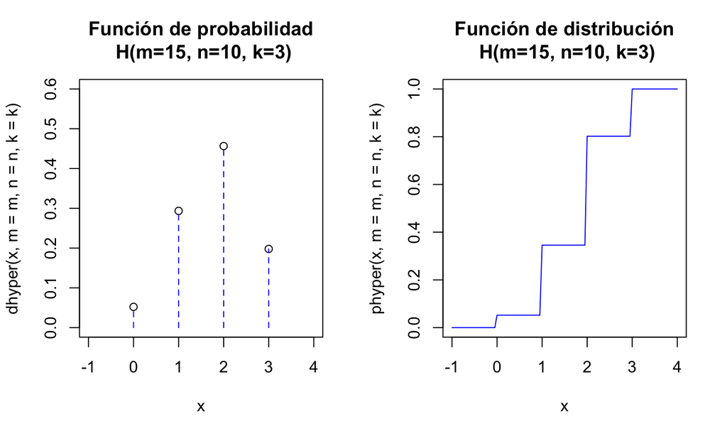